# 2021-11-16 R Solo Project JG

```r
library(tidyverse)
```

1. Read in `districts.csv` into a tibble named `districts`. How many rows and columns does it contain? 146 rows x 27 columns

```r
districts<- read_csv('../data/districts.csv')
```

```r
districts
```

| system | system_name | alg_1 | alg_2 | bio | chem | ela | eng_1 | eng_2 | eng_3 | math | science | enrollment | black | hispanic | native | el | swd | ed | expenditures | act_composite | chronic_abs | suspended | expelled | grad | dropout | region |
| --- | --- | --- | --- | --- | --- | --- | --- | --- | --- | --- | --- | --- | --- | --- | --- | --- | --- | --- | --- | --- | --- | --- | --- | --- | --- | --- |
| 0 | State of Tennessee | 70.0 | 54.3 | 65.3 | 44.2 | 48.4 | 71.8 | 64.8 | 41.7 | 54.7 | 64.5 | 943699 | 24.1 | 8.5 | 0.3 | 4.6 | 14.0 | 57.9 | 9374.9 | 19.4 | 13.2 | 6.2 | 0.2 | 87.2 | 8.4 | NA |
| 10 | Anderson County | 76.1 | 63.3 | 73.6 | 41.0 | 45.7 | 73.7 | 59.2 | 38.2 | 54.0 | 64.5 | 6304 | 2.8 | 1.1 | 0.5 | 0.2 | 18.0 | 58.5 | 9535.7 | 19.9 | 11.5 | 5.0 | 0.1 | 94.0 | 4.2 | East TN |
| 11 | Clinton City | NA | NA | NA | NA | 58.3 | NA | NA | NA | 68.9 | 69.6 | 894 | 5.7 | 2.8 | 0.3 | 1.0 | 18.1 | 63.4 | 9537.5 | NA | 8.8 | 1.2 | 0.0 | NA | NA | East TN |
| 12 | Oak Ridge City | 76.9 | 72.0 | 83.5 | 80.9 | 56.1 | 86.7 | 74.6 | 53.8 | 55.3 | 70.8 | 4326 | 16.6 | 8.0 | 0.7 | 3.0 | 14.3 | 52.5 | 12355.5 | 23.1 | 17.5 | 5.7 | 0.0 | 89.7 | 4.4 | East TN |
| 20 | Bedford County | 64.3 | 42.4 | 62.1 | 32.5 | 44.1 | 72.3 | 63.1 | 44.6 | 53.1 | 61.8 | 8270 | 11.2 | 20.6 | 0.5 | 9.4 | 10.9 | 69.9 | 7756.2 | 18.4 | 8.6 | 2.2 | 0.0 | 90.8 | 5.4 | South Central |
| 30 | Benton County | 73.7 | 58.4 | 77.1 | 33.1 | 46.0 | 75.4 | 60.8 | 45.6 | 53.9 | 65.0 | 2133 | 3.9 | 2.1 | 0.3 | 0.0 | 18.8 | 50.2 | 9714.2 | 18.4 | 6.5 | 0.0 | 0.0 | 94.5 | 3.0 | Northwest |
| 40 | Bledsoe County | 64.8 | 73.9 | 73.0 | 19.5 | 35.4 | 63.6 | 53.3 | 50.0 | 41.1 | 56.2 | 1674 | 1.5 | 6.8 | 0.6 | 2.3 | 19.7 | 83.5 | 9495.9 | 19.2 | 9.1 | 2.4 | 0.1 | 92.4 | 6.9 | Upper Cumberland |
| 50 | Blount County | 73.2 | 59.8 | 65.1 | 45.4 | 46.3 | 71.8 | 66.0 | 45.3 | 50.5 | 68.4 | 10500 | 3.0 | 4.2 | 0.4 | 1.9 | 12.8 | 54.2 | 8866.9 | 19.7 | 17.0 | 4.7 | 0.1 | 89.1 | 9.2 | East TN |
| 51 | Alcoa City | 82.2 | 76.8 | 88.0 | 66.0 | 50.2 | 85.5 | 79.6 | 67.2 | 56.6 | 65.1 | 1850 | 23.3 | 9.5 | 0.6 | 2.7 | 13.0 | 49.4 | 10320.0 | 22.0 | 4.7 | 3.1 | 0.1 | 98.2 | 0.9 | East TN |
| 52 | Maryville City | 83.8 | 77.3 | 92.1 | 80.4 | 69.6 | 89.9 | 82.7 | 68.1 | 70.2 | 87.1 | 4944 | 4.2 | 4.0 | 0.2 | 2.8 | 13.2 | 32.1 | 10161.2 | 23.0 | 2.0 | 2.7 | 0.0 | 96.6 | 3.1 | East TN |

[output cut: 136 more lines]

2. Notice that the first row corresponds to the whole State of Tennessee. Remove this row and save the result back to `districts`.

```r
districts<-districts %>%
  filter(system_name != 'State of Tennessee')
```

3. How many districts have a proficiency rate of at least 80% for both alg_1 and eng_1? 13 districts

```r
districts %>%
  filter(alg_1 >= 80, eng_1 >= 80)
```

| system | system_name | alg_1 | alg_2 | bio | chem | ela | eng_1 | eng_2 | eng_3 | math | science | enrollment | black | hispanic | native | el | swd | ed | expenditures | act_composite | chronic_abs | suspended | expelled | grad | dropout | region |
| --- | --- | --- | --- | --- | --- | --- | --- | --- | --- | --- | --- | --- | --- | --- | --- | --- | --- | --- | --- | --- | --- | --- | --- | --- | --- | --- |
| 51 | Alcoa City | 82.2 | 76.8 | 88.0 | 66.0 | 50.2 | 85.5 | 79.6 | 67.2 | 56.6 | 65.1 | 1850 | 23.3 | 9.5 | 0.6 | 2.7 | 13.0 | 49.4 | 10320.0 | 22.0 | 4.7 | 3.1 | 0.1 | 98.2 | 0.9 | East TN |
| 52 | Maryville City | 83.8 | 77.3 | 92.1 | 80.4 | 69.6 | 89.9 | 82.7 | 68.1 | 70.2 | 87.1 | 4944 | 4.2 | 4.0 | 0.2 | 2.8 | 13.2 | 32.1 | 10161.2 | 23.0 | 2.0 | 2.7 | 0.0 | 96.6 | 3.1 | East TN |
| 273 | Trenton SSD | 91.6 | 84.7 | 75.6 | 64.5 | 44.6 | 82.6 | 76.0 | 50.6 | 62.9 | 53.6 | 1278 | 28.2 | 6.0 | 0.0 | 0.1 | 12.7 | 66.1 | 8916.6 | 18.6 | 10.5 | 2.8 | 0.0 | 83.5 | 11.0 | Northwest |
| 274 | Bradford SSD | 94.4 | 92.6 | 87.9 | 66.7 | 56.5 | 81.8 | 68.4 | 70.4 | 73.4 | 75.4 | 499 | 6.1 | 0.6 | 0.0 | 0.0 | 17.3 | 62.8 | 10143.5 | 18.7 | 11.4 | 0.9 | 0.0 | 100.0 | 0.0 | Northwest |
| 275 | Gibson County SSD | 83.7 | 73.2 | 75.3 | 63.0 | 57.8 | 83.8 | 73.5 | 59.6 | 67.5 | 79.7 | 3832 | 7.8 | 2.0 | 0.0 | 0.4 | 13.3 | 42.3 | 7270.0 | 19.7 | 8.2 | 0.0 | 0.0 | 94.9 | 4.0 | Northwest |
| 301 | Greeneville City | 83.2 | 90.2 | 77.7 | 86.1 | 59.3 | 87.3 | 75.1 | 66.0 | 65.5 | 74.2 | 2674 | 9.8 | 7.8 | 0.9 | 3.0 | 16.6 | 47.2 | 10862.5 | 21.3 | 9.1 | 4.5 | 0.0 | 98.6 | 0.5 | First TN |
| 390 | Henderson County | 86.0 | 88.4 | 76.4 | 53.7 | 53.3 | 81.1 | 77.7 | 51.8 | 72.1 | 71.2 | 3781 | 8.1 | 2.2 | 0.0 | 0.0 | 14.5 | 61.4 | 8412.5 | 19.5 | 10.8 | 0.0 | 0.0 | 96.4 | 2.4 | Southwest/Memphis |
| 793 | Arlington City | 88.0 | 66.9 | 82.5 | 49.8 | 75.7 | 88.8 | 78.1 | 50.7 | 75.1 | 88.3 | 4819 | 16.0 | 5.3 | 0.4 | 2.2 | 11.0 | 13.9 | 7705.1 | 21.1 | 7.9 | 2.3 | 0.1 | 94.0 | 4.4 | Southwest/Memphis |
| 795 | Collierville City | 90.2 | 85.6 | 87.4 | 80.4 | 75.1 | 92.5 | 86.2 | 66.2 | 75.7 | 86.8 | 7774 | 17.5 | 4.3 | 0.4 | 4.0 | 13.4 | 15.0 | 8383.2 | 24.0 | 5.9 | 2.8 | 0.3 | 93.0 | 2.7 | Southwest/Memphis |
| 796 | Germantown City | 90.0 | 84.2 | 88.9 | 78.5 | 79.4 | 90.8 | 87.7 | 70.8 | 74.3 | 88.0 | 5624 | 12.3 | 3.1 | 0.3 | 2.6 | 9.8 | 9.6 | 7930.8 | 24.1 | 5.1 | 1.3 | 0.0 | 88.7 | 7.9 | Southwest/Memphis |

[output cut: 3 more lines]

```r
districts %>%
  filter(alg_1<50, eng_1<50)
```

| system | system_name | alg_1 | alg_2 | bio | chem | ela | eng_1 | eng_2 | eng_3 | math | science | enrollment | black | hispanic | native | el | swd | ed | expenditures | act_composite | chronic_abs | suspended | expelled | grad | dropout | region |
| --- | --- | --- | --- | --- | --- | --- | --- | --- | --- | --- | --- | --- | --- | --- | --- | --- | --- | --- | --- | --- | --- | --- | --- | --- | --- | --- |
| 480 | Lake County | 22.9 | NA | 25.0 | 36.5 | 32.5 | 36.8 | 34.6 | 31.7 | 34.7 | 45.6 | 807 | 30.2 | 3.3 | 0.1 | 0.1 | 18.6 | 77.0 | 10813.0 | 16.4 | 31.2 | 5.5 | 0.1 | 89.4 | 6.4 | Northwest |
| 985 | Achievement School District | 34.0 | 20.4 | 20.6 | NA | 14.3 | 37.8 | 33.0 | 8.2 | 23.3 | 26.1 | 6370 | 96.7 | 1.5 | 0.0 | 1.1 | 12.9 | 96.6 | 12804.4 | 14.2 | 27.2 | 21.4 | 0.1 | 54.7 | 27.6 | Southwest/Memphis |

5. Which district has the lowest graduation rate? Tenn School for Blind

```r
districts %>%
  select(system_name, grad) %>%
  arrange(grad)
```

| system_name | grad |
| --- | --- |
| Tenn School for Blind | 11.1 |
| Achievement School District | 54.7 |
| Humboldt City | 68.5 |
| Shelby County | 72.1 |
| Tenn School for Deaf | 77.8 |
| Millington City | 78.2 |
| Davidson County | 78.7 |
| Fayette County | 80.6 |
| Bartlett City | 81.3 |
| Alvin C. York Institute | 81.3 |

[output cut: 135 more lines]

6. Which district has the highest dropout rate? Achievement School district

```r
districts %>%
  select(system_name, dropout) %>%
  arrange(desc(dropout))
```

| system_name | dropout |
| --- | --- |
| Achievement School District | 27.6 |
| Humboldt City | 20.2 |
| Shelby County | 17.6 |
| Millington City | 16.7 |
| Fayette County | 15.9 |
| Davidson County | 14.6 |
| Alvin C. York Institute | 14.2 |
| Sequatchie County | 13.0 |
| Dyersburg City | 12.5 |
| Cleveland City | 12.3 |

[output cut: 135 more lines]

7. Within the Mid Cumberland region, which district has the highest ACT composite? Williamson County

```r
districts %>%
  filter(region == 'Mid Cumberland') %>%
  arrange(desc(act_composite))
```

| system | system_name | alg_1 | alg_2 | bio | chem | ela | eng_1 | eng_2 | eng_3 | math | science | enrollment | black | hispanic | native | el | swd | ed | expenditures | act_composite | chronic_abs | suspended | expelled | grad | dropout | region |
| --- | --- | --- | --- | --- | --- | --- | --- | --- | --- | --- | --- | --- | --- | --- | --- | --- | --- | --- | --- | --- | --- | --- | --- | --- | --- | --- |
| 940 | Williamson County | 90.3 | 84.8 | 89.2 | 81.0 | 80.7 | 92.9 | 88.7 | 68.6 | 80.3 | 91.1 | 34395 | 5.0 | 5.3 | 0.7 | 1.7 | 10.2 | 9.6 | 8739.7 | 23.8 | 7.0 | 0.2 | 0.0 | 94.4 | 4.4 | Mid Cumberland |
| 220 | Dickson County | 68.4 | 56.6 | 69.6 | 42.8 | 52.2 | 82.8 | 71.7 | 44.5 | 59.6 | 75.8 | 8120 | 8.1 | 4.9 | 0.6 | 1.6 | 16.2 | 53.1 | 8472.8 | 21.0 | 12.2 | 0.5 | 0.0 | 90.7 | 7.4 | Mid Cumberland |
| 110 | Cheatham County | NA | NA | 73.3 | 53.1 | 46.4 | 75.5 | 57.7 | 47.9 | 55.7 | 66.4 | 6240 | 2.6 | 3.6 | 0.4 | 1.1 | 15.3 | 49.1 | 8412.6 | 20.8 | 13.4 | 5.8 | 0.1 | 91.2 | 5.9 | Mid Cumberland |
| 830 | Sumner County | 73.8 | 59.4 | 68.6 | 52.6 | 60.3 | 76.0 | 70.0 | 48.5 | 67.7 | 72.5 | 27724 | 10.8 | 6.5 | 0.3 | 2.0 | 15.3 | 36.7 | 8402.0 | 20.4 | 9.3 | 2.4 | 0.0 | 89.5 | 7.0 | Mid Cumberland |
| 950 | Wilson County | 69.8 | 58.0 | 74.1 | 45.4 | 60.6 | 78.1 | 76.1 | 44.0 | 65.3 | 81.9 | 16507 | 8.1 | 4.6 | 0.1 | 2.2 | 14.4 | 29.2 | 7690.8 | 20.0 | 11.6 | 4.8 | 0.0 | 96.3 | 2.9 | Mid Cumberland |
| 750 | Rutherford County | 74.6 | 59.9 | 73.0 | 59.9 | 58.7 | 79.6 | 72.0 | 48.1 | 64.9 | 76.9 | 40841 | 18.6 | 11.6 | 0.2 | 5.9 | 11.0 | 39.7 | 8237.1 | 19.9 | 20.5 | 4.2 | 0.3 | 92.5 | 4.5 | Mid Cumberland |
| 630 | Montgomery County | 74.1 | 67.9 | 76.8 | 52.8 | 55.6 | 77.2 | 70.6 | 47.9 | 63.5 | 78.1 | 30670 | 28.2 | 11.5 | 1.0 | 2.7 | 14.2 | 49.4 | 8675.5 | 19.4 | 6.0 | 5.3 | 0.3 | 93.4 | 4.0 | Mid Cumberland |
| 740 | Robertson County | 73.3 | 58.5 | 65.4 | 42.4 | 47.5 | 78.3 | 67.7 | 42.3 | 55.5 | 58.1 | 11001 | 11.3 | 12.1 | 0.2 | 6.6 | 15.3 | 51.6 | 8077.1 | 19.4 | 10.3 | 4.7 | 0.0 | 95.1 | 3.3 | Mid Cumberland |
| 810 | Stewart County | 77.6 | 80.7 | 66.7 | 68.9 | 54.8 | 82.5 | 70.7 | 59.4 | 68.9 | 80.0 | 1950 | 2.6 | 2.1 | 0.6 | 0.1 | 13.4 | 49.1 | 9003.3 | 19.4 | 22.5 | 1.3 | 0.0 | 96.1 | 1.9 | Mid Cumberland |
| 420 | Houston County | 58.6 | 64.9 | 69.4 | 34.0 | 44.5 | 60.4 | 66.4 | 48.6 | 55.9 | 63.0 | 1298 | 5.1 | 2.2 | 0.7 | 0.0 | 16.3 | 56.7 | 9187.7 | 19.2 | 26.3 | 0.2 | 0.0 | 95.8 | 3.1 | Mid Cumberland |

[output cut: 6 more lines]

```r
NA
```

8. Create a histogram showing the distribution of graduation rates. What can you say about this distribution? Left Skewed Unimodal. Possibly some outliers on the lower end of graduation rate.

```
Warning: Removed 17 rows containing non-finite values (stat_bin).
```

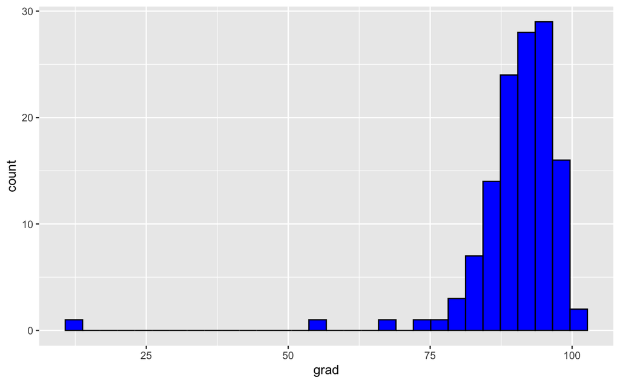

```r
districts %>%
  ggplot(aes(grad))+
  geom_histogram(fill = 'blue', color = 'black')
```

9. Create a scatter plot to compare alg_1 proficiency rates to alg_2 rates. What do you notice? Facet this plot by region. Does anything stand out when you facet the plots? There is a positive correlation with Alg1 efficiency rates and alg 2 proficiency rates Facet: Most districts have a positive correlation, but upper cumberland has a slightly negative correlation.

```
Warning: Removed 28 rows containing non-finite values (stat_smooth).
Warning: Removed 28 rows containing missing values (geom_point).
```

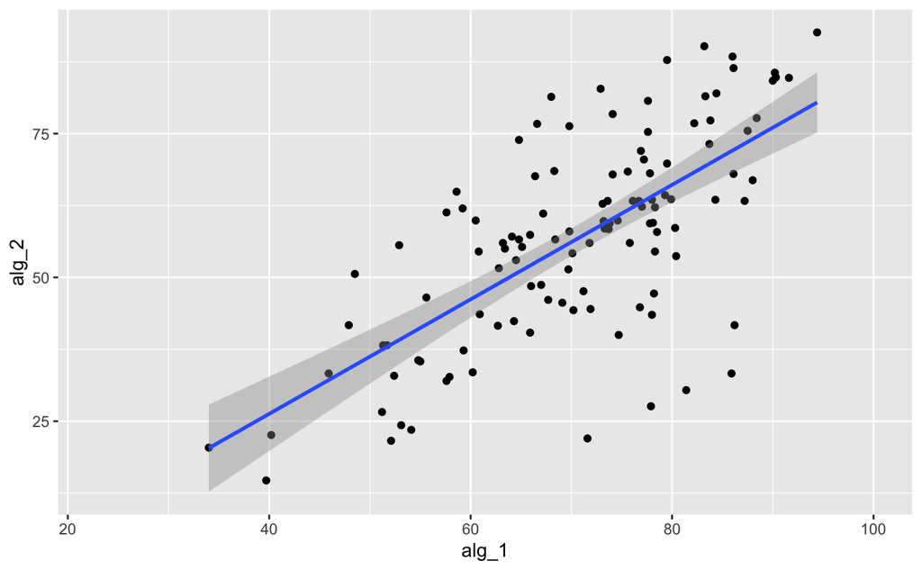

```r
districts %>%
  ggplot(aes(x= alg_1, y = alg_2))+
  geom_point()+
  geom_smooth(method = 'lm')
```

```
Warning: Removed 28 rows containing non-finite values (stat_smooth).
Warning: Removed 28 rows containing missing values (geom_point).
```

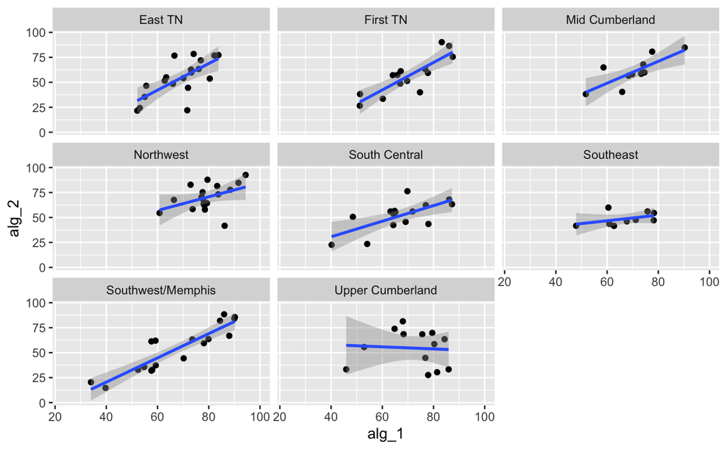

```r
districts %>%
  ggplot(aes(x= alg_1, y = alg_2))+
  geom_point()+
  geom_smooth(method = 'lm')+
  facet_wrap(~region)
```

10. Create a bar chart showing the total enrollment by region. Which region has the highest total enrollment? Which has the smallest? Highest: MidCumberland Smallest: Northwest

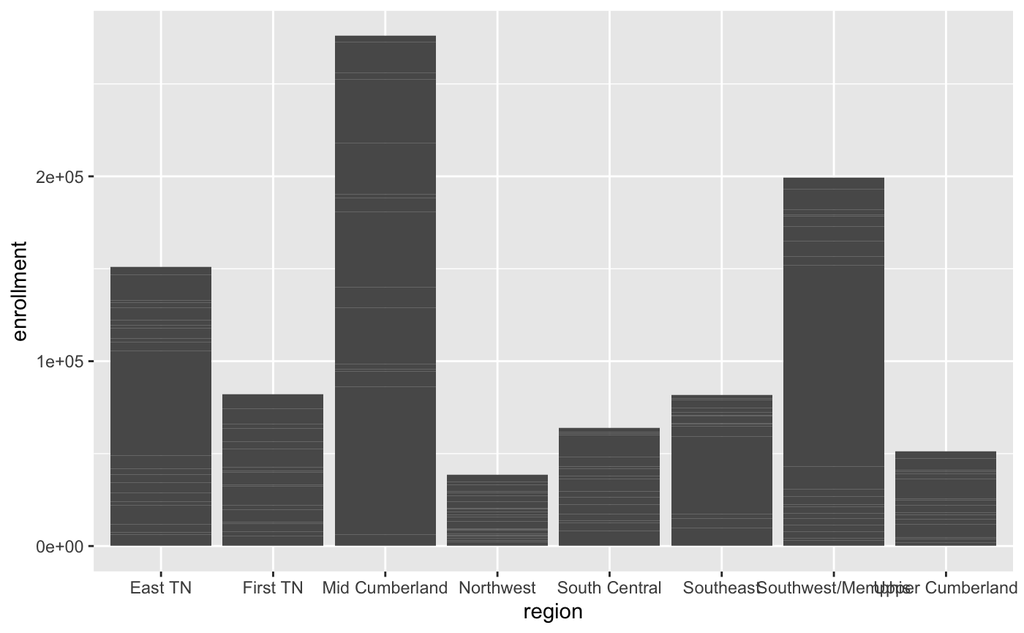

```r
ggplot(districts, aes(x = region, y = enrollment)) +
  geom_col()
```

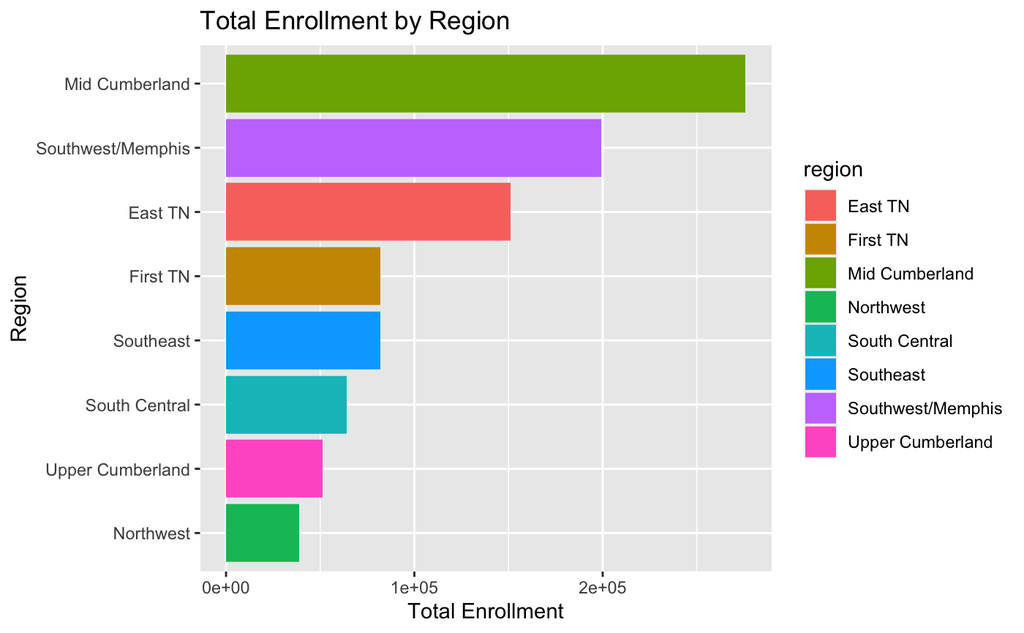

```r
districts %>%
  group_by(region) %>%
  summarize(total_enrollment = sum(enrollment, na.rm = TRUE)) %>%
  mutate(regionfct = factor(region)) %>%
  mutate(regionfct = fct_reorder(regionfct, total_enrollment, .desc = FALSE)) %>%
  ggplot(aes(y = regionfct , x = total_enrollment, fill = region)) +
    geom_col() +
    labs(title = "Total Enrollment by Region",
         x = "Total Enrollment",
         y = "Region")
```

11. When creating this bar chart you may have noticed that some districts have missing enrollment values. For how many districts is this the case? 4 districts have NA for their enrollment. EastTN, MidCumblerand, Southwest/Memphis, and UpperCumberland all have 1 NAs in one of their districts.

```r
districts %>%
  group_by(region) %>%
  summarize(NAs = sum(is.na(enrollment))) %>%
  arrange(desc(NAs))
```

| region | NAs |
| --- | --- |
| East TN | 1 |
| Mid Cumberland | 1 |
| Southwest/Memphis | 1 |
| Upper Cumberland | 1 |
| First TN | 0 |
| Northwest | 0 |
| South Central | 0 |
| Southeast | 0 |

12. What is the mean graduation rate across all districts? What might be wrong with using just the regular mean to assess average graduation rates? 90.1% is the mean graduation rate. Not all districts have the same population.

```r
districts %>%
  summarise(avg_gradrate = mean(grad, na.rm = TRUE))
```

| avg_gradrate |
| --- |
| 90.06562 |

13. Redo the previous question but use a weighted average (`weighted.mean`) graduation across all districts, weighing by enrollment. How much does this change your answer? Can you explain using the data the reason for the big change from using the mean? The weighted average is lower than the average of all districts. Nashville, Memphis are the two largest cities in the state and are in the southwest/memphis or Mid cumberland region and their grad rates are not near 90%. With their higher populations, they drag the average down.

```r
districts %>%
  filter(!is.na(grad), !is.na(enrollment)) %>%
  summarise(avg_gradrate_wt = weighted.mean(grad, enrollment))
```

| avg_gradrate_wt |
| --- |
| 87.33285 |

```r
NA
```

14. Create a boxplot showing enrollment rates per region. Does anything stand out? The spread of the quartiles for mid cumberland is a higher than other regions.

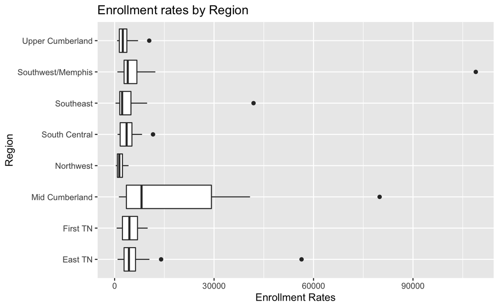

```r
districts %>%
  group_by(region) %>%
  ggplot(aes(y = region , x = enrollment)) +
    geom_boxplot() +
    labs(title = "Enrollment rates by Region",
         x = "Enrollment Rates",
         y = "Region")
```

15. Create a boxplot showing graduation rates per region. Does anything stand out?

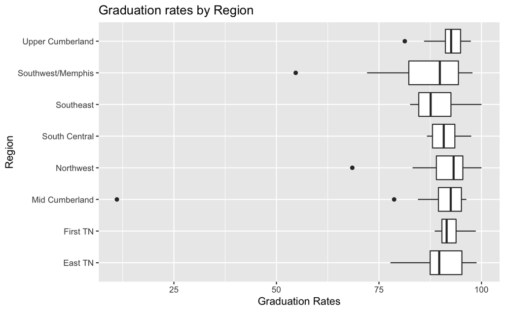

```r
districts %>%
  group_by(region) %>%
  ggplot(aes(y = region , x = grad)) +
    geom_boxplot() +
    labs(title = "Graduation rates by Region",
         x = "Graduation Rates",
         y = "Region")
```

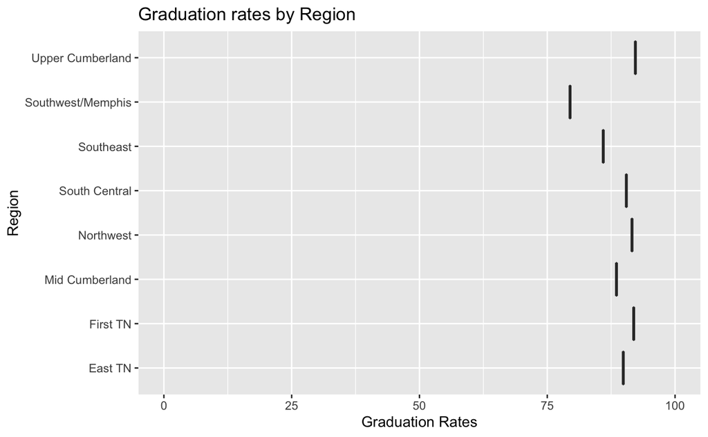

```r
districts %>%
  group_by(region) %>%
  filter(!is.na(grad), !is.na(enrollment)) %>%
  summarise(avg_gradrate_wt_region = weighted.mean(grad, enrollment)) %>%
  ggplot(aes(y = region , x = avg_gradrate_wt_region)) +
    geom_boxplot() +
    labs(title = "Graduation rates by Region",
         x = "Graduation Rates",
         y = "Region")+
  xlim(0,100)
```

16. Find the weighted average of graduation rates by region using enrollment as weights. Compare the results you get for the weighted average to what you see from the boxplots. Can you explain any discrepancy? Southwest/Memphis’s weight average is considerably lower.

```r
districts %>%
  group_by(region) %>%
  filter(!is.na(grad), !is.na(enrollment)) %>%
  summarise(avg_gradrate_wt_region = weighted.mean(grad, enrollment)) %>%
  arrange(desc(avg_gradrate_wt_region))
```

| region | avg_gradrate_wt_region |
| --- | --- |
| Upper Cumberland | 92.24062 |
| First TN | 91.91454 |
| Northwest | 91.57705 |
| South Central | 90.47392 |
| East TN | 89.87089 |
| Mid Cumberland | 88.53965 |
| Southeast | 85.95494 |
| Southwest/Memphis | 79.45971 |

```r
districts %>%
  mutate(alg=alg_1-alg_2) %>%
  ggplot( aes(x = alg))+
  geom_histogram(fill = 'blue', color = 'black')
```

[output not shown]

```r
districts %>%
  mutate(alg=alg_1-alg_2) %>%
  top_n(1)
```

| system | system_name | alg_1 | alg_2 | bio | chem | ela | eng_1 | eng_2 | eng_3 | math | science | enrollment | black | hispanic | native | el | swd | ed | expenditures | act_composite | chronic_abs | suspended | expelled | grad | dropout | region | alg |
| --- | --- | --- | --- | --- | --- | --- | --- | --- | --- | --- | --- | --- | --- | --- | --- | --- | --- | --- | --- | --- | --- | --- | --- | --- | --- | --- | --- |
| 690 | Pickett County | 85.9 | 33.3 | 69.4 | 29.9 | 33.5 | 77 | 65.2 | 29.1 | 28.9 | 52.7 | 733 | 0.8 | 2.3 | 0 | 0 | 14.7 | 65.3 | 8184.2 | 19.7 | 13.6 | 0.1 | 0 | 94.4 | 0 | Upper Cumberland | 52.6 |

```r
districts %>%
  filter(is.na(alg_1)) %>%
  count()
```

```r
districts %>%
  filter(is.na(alg_2)) %>%
  count()
```

```r
mathwizards<-districts %>%
  filter(!is.na(alg_1), !is.na(alg_2)) %>%
  filter(when(alg_2, alg_2>alg_1))
#this only has the sum of districts where alg2 is greater than alg1. I need to divide by the total number of districts where alg1/2 is not Na. Find out how many in each one that are NA. there may not be any or may be a lot.
#21 NAs for alg_1, 25 NAs for alg_2
```

```r
wordwizards <- districts %>%
  filter(!is.na(eng_3, !is.na(eng_2))) %>%
  filter(when(eng_3, eng_3>eng_2))
```

[output not shown]

[output not shown]

18. You may have noticed that a lot of rows are missing values. Which district has the largest number of missing values? What do you notice about schools that have a lot of missing values? West Tenn School for the Deaf has the most NAs. There are quite a few schools that are ‘Special School Districts’, which from doing a little digging, look like districts within districts. They also appear to be tied to desegregation and unfortunately as a way to resist integration. https://www.washingtonpost.com/education/2019/12/16/lines-that-divide-school-district-boundaries-often-stymie-integration/

[output not shown]

[output cut: 135 more lines]

19. Find the correlation between graduation rate and all other variables. Create a horizontal bar chart showing these correlations. Make sure that your plot is ordered by correlation values. What do you notice from these correlations?

```r
districts_corr <- districts %>%
  select(where(is.numeric)) %>%
  cor(use = 'pairwise.complete.obs') %>%
  select(term, grad)
```

[output not shown]

```r
districts_corr %>%
  ggplot()+
  geom_col()
```

[output not shown]

20. Create a scatterplot for `grad` vs. `suspended`. Does what you see make sense given your answer from the previous part?
21. Create a linear regression model using `lm` with target variable `grad` and predictor variable `suspended`. What R^2 value does this model have? What is the interpretation of this number?
22. Add the regression line to your scatterplot using `geom_smooth` with `method='lm'`. How do you feel about the regression line after seeing it plotted on the scatterplot?

**Continued Exploration and Practice**

23. Read in the school-level testing data for 2014, available [here](https://www.tn.gov/content/dam/tn/education/data/data_2014_school_base.xlsx). You might find the readxl library useful for this task. If you use this library, be sure to look at the `na` argument for the `read_excel` function.
24. How many schools have at least 20 percent of students below bsc for Algebra I? Which districts do these schools belong to?
25. How many schools have at least 20 percent of students below bsc for *both* Algebra I and English I?
26. Which grade has the highest pct_adv for Algebra I? Plot the average pct_adv per grade level as a bar chart. Make sure that the bars are ordered by grade level.
27. Find the correlation between pct_adv for Algebra I and pct_adv for Algebra II by school. Create a scatterplot showing Algebra II scores vs. Algebra I scores by school.
28. Find all schools in Rutherford County that have “High School” in their name. For these schools, create a chart (your choice) showing the differences in pct_below_bsc, pct_bsc, pct_prof, and pct_adv for Algebra I when looking across all subgroups and grades.
29. I claim that smaller schools do a better job preparing students for Algebra I standardized tests. Find the average number of valid tests (a proxy for the school size) for schools where the pct_prof_adv for Algebra I is greater than 95. Compare this to the average number of valid tests for all schools. In light of this result, how does my claim look?
30. I also claim that smaller schools do a worse job preparing students for Algebra I standardized tests. Find the average number of valid tests (a proxy for the school size) for schools where the pct_prof_adv for Algebra I is less than 25. Compare this to the average number of valid tests for all schools. In light of this result, how does my claim look now?
31. Create a scatterplot showing pct_prov_adv vs. valid_tests. Can you use this to explain the result for numbers 26 and 27?

If you finish all of the above questions, continue to explore the two datasets and see what else interesting you can find.

Also, check out the plotly library for R. The `ggplotly` function makes it very easy to convert ggplot plots into interactive plotly plots.